# Final Assignment - Predictive Analytics - Actuarial Program

Phạm Quang Minh - 11230468

Đinh Nho Thái Sơn - 11230486

Nguyễn Đức Quang - 11230482

Cù Huệ Linh - 11230452

May 2026

# (a) Data Loading and Preprocessing

## 1. Reading the Dataset

The dataset train.csv is loaded using `data.table::fread()`, a high-performance reader chosen for its speed on moderately large tabular files. The critical loading argument is `integer64 = "numeric"`, which forces any 64-bit integer columns to be coerced to R’s native numeric (double precision). Without this, large monetary totals such as annual salary sums would silently overflow R’s 32-bit integer bounds.

```r
TRAIN_PATH <- "train.csv"
train <- data.table::fread(TRAIN_PATH, integer64 = "numeric")
```

The training set contains **25,873 rows** and **32 columns**. Each row represents one insured individual. The primary key is `ID`, formatted as `<household_code>_<member_index>` (e.g., `00001037008_2`). This dual-purpose key encodes both the household the person belongs to and their ordinal position within it — a structure that the pipeline later exploits to build household-level aggregate features.

The target variable `y` is a continuous, right-skewed cost measure bounded within [0, 15], with **a positive rate of approximately 18.3%**. This means roughly 82% of individuals incurred zero healthcare cost in the observed period — a strong zero-inflation that directly motivates the hurdle model architecture used in Steps 1 and 2.

Immediately after loading, a sanity check confirms that y is consistent with `log1p(COST_NGOAITRU + COST_NOITRU)`, verifying that the target is a log-transformed total insurance cost rather than a raw value:

```r
cost_sum  <- data.table::fifelse(is.na(train$COST_NGOAITRU), 0, train$COST_NGOAITRU) +
             data.table::fifelse(is.na(train$COST_NOITRU),   0, train$COST_NOITRU)
y <- train$y
max_delta <- max(abs(y - log1p(cost_sum)))
```

## 2. Handling Missing Values

The dataset has pervasive missingness, particularly in financial and employment columns. The table below summarises the key missing patterns:

| **Column Group** | **Missing (~)** | **Interpretation** |
| --- | --- | --- |
| `TIEN_LUONG_12T`, `TIEN_LE_TET`, `THUONG_PHU_CAP`, `CO_DUOC_KY_HOP_DONG` | 18,622 | Individual has no primary employment |
| `LUONG_CONG_VIEC_2`, `TIEN_LE_TET_2`, `THUONG_PHU_CAP_2`, `CO_DUOC_KY_HOP_DONG_2` | 25,132 | No second job recorded |
| `LUONG_CHO_NGHI_HUU_BINH_THUONG`, `LUONG_CHO_NGHI_HUU_SOM`, `TRO_CAP_MAT_SUC_LAO_DONG` | ~24,925 | Not retired/no disability benefit |
| `LOAI_THE_2` | 9,875 | No secondary insurance card |
| `MARRIED_STATUS`, `CO_LAM_VIEC`, `LOAI_THE_1` | 2,000-5,000 | Partially recorded demographics |

Critically, the pipeline does **not** impute missing values with a global mean or median. Instead, it adopts a **domain-aware strategy**: for all monetary columns, NA is treated as a structural zero, the individual simply has no income from that source. Three derived columns are created per monetary variable: - **A binary missingness indicator** (`col_missing`), capturing whether the value was absent at all. - **A zero-filled raw value** (`col_zero`), for direct use in sums such as total household income. - **A log-transformed version** (`col_log1p`), applying log1p(max(z, 0)) to compress the heavy right-skewed distribution.

```r
all_dt[, paste0(col, '_missing') := as.integer(is.na(raw))]
all_dt[, paste0(col, '_zero')    := z]
all_dt[, paste0(col, '_log1p')   := log1p(pmax(z, 0.0))]
```

For categorical columns, NA is replaced by the explicit sentinel string “**NA**” before encoding. This ensures that missingness is treated as a **distinct learnable category** rather than being dropped from tree splits, so models can learn whether the absence of an insurance card type or marital status is itself predictive of cost:

```r
cat_value <- function(x) {
  out <- as.character(x)
  out[is.na(out)] <- NA_CHR   # "__NA__"
  out
}
```

For household-level target-encoded features (e.g., mean `y` of other household members), any remaining `NA` values that appear after the group join for households appearing only in the test set are replaced with **global training-set averages** computed by `global_target_defaults()`. This provides a sensible fallback without introducing data leakage.

## 3. Outlier Handling

The pipeline does **not** apply explicit outlier removal or clipping to raw feature values. This is appropriate because both LightGBM and XGBoost are tree-based models inherently robust to extreme values, splits are based on rank-ordering, not absolute magnitude, so a very large salary or an unusual age does not distort training the way it would in a linear model.

Instead, the outlier control is applied to **model predictions** rather than inputs, via two clipping functions:

```r
clip_pred     <- function(pred) pmin(pmax(pred, PRED_MIN), PRED_MAX)
                 # enforces [0, 15] — cost cannot be negative;
                 # empirical max in train is ~14.15

clip_residual <- function(x, limit = RESID_CLIP) pmin(pmax(x, -limit), limit)
                 # RESID_CLIP = 1.5 — limits residual correction
                 # in Step 5 to avoid overcorrection on outliers
```

The lower bound `PRED_MIN = 0` enforces the physical constraint that cost cannot be negative, while `PRED_MAX = 15.0` reflects that no training sample exceeds this value (maximum observed `y` ≈ 14.15). The residual clip `RESID_CLIP = 1.5` is a tunable parameter that controls how conservatively the final residual-correction stage (Step 5) adjusts the base ensemble prediction.

## 4. Transformations Applied

Beyond missing value handling, a comprehensive set of transformations is applied during feature engineering. These are summarised in the table below and described in detail in the following subsections:

| **Transformation** | **Applied To** | **Purpose** |
| --- | --- | --- |
| `log1p()` | All monetary columns (after zero-fill) | Compress right-skewed income/cost distributions; stabilise gradient-based training |
| Zero-fill + missing flag | All `MONEY_COLS` with NA | Structural zeros (no income source) + preserve missingness signal as binary feature |
| `age\^2`, `log1p(AGE)` | `AGE` | Capture nonlinear health-cost curvature across life stages |
| 8-bin discretisation | `AGE` | Domain-aware breakpoints: 0-5, 6-12, 13-18, 19-30, 31-45, 46-60, 61-75, 76+ |
| Label encoding (integer) | All categoricals + interactions | Enables native categorical splits in LightGBM/XGBoost without ordinal assumption |
| NA sentinel `'__NA__'` | Categorical NAs | Treats missingness as a learnable category rather than excluding from splits |
| ID decomposition | ID column | Extracts household code + member index; generates prefix-based geo features |
| Leave-one-out target encoding | Household-level target statistics | Leakage-free within-fold group statistics for y, cost, and frequency |
| Prediction clipping [0, 15] | Model output | Enforce domain bounds (cost ≥ 0; empirical max ~14.15) |
| Residual clipping [-1.5, 1.5] | Residual correction (Step 5) | Prevent overcorrection on extreme observations |

### 4.1 Log Transformation of Monetary Columns

All income and insurance cost variables are transformed with `log1p()` after zero-filling missing values. This compresses the heavily right-skewed distribution of monetary amounts (where most values are zero or small, but a few are very large) and places observations on a more comparable scale, improving the stability of gradient-based optimisation inside both LightGBM and XGBoost:

```r
all_dt[, paste0(col, '_log1p') := log1p(pmax(z, 0.0))]
```

Composite income variables `income_job1`, `income_job2`, `income_job3`, and income_total are also constructed as column sums and then log-transformed. These aggregates allow the model to reason about total economic capacity rather than individual pay components.

### 4.2 Age Features

Raw age is supplemented with several derived representations to capture the nonlinear relationship between age and healthcare cost: - `AGE^2` and `log1p(AGE)`: polynomial and log transforms to fit the U-shaped cost curve across life stages. - Binary flags: `is_child` (age < 15), `is_working_age` (15–64), `is_elder` (age ≥ 60). - `age_bin`: 8 domain-meaningful brackets (0–5, 6–12, 13–18, 19–30, 31–45, 46–60, 61–75, 76+), treated as a categorical feature.

### 4.3 Categorical Encoding

After `NA` replacement with the `"__NA__"` sentinel, all categorical variables are label-encoded to integers using a vocabulary built jointly from both train and test sets. Unseen values at inference time are mapped to `-1`. The resulting integer columns are explicitly declared as categorical to the learners (`categorical_feature` in LightGBM; `feature_types = "c"` in XGBoost), enabling optimal many-valued split-finding algorithms rather than treating codes as ordinal numbers.

### 4.4 ID Decomposition and Household Features

The ID column is parsed with `tstrsplit(..., "_")` to extract the household code and member index. The household code is further truncated to prefixes of length 2, 3, 4, 5, 6, 8, and 11 characters, creating geographic proxy features (`hh_pref2`, …, `hh_pref11`) that implicitly encode administrative region at different resolutions. Household-level aggregate features are then computed across all members: mean/min/max/std of age, income, and education level, as well as counts of children, elderly, and insured members and joined back to each individual row.

### 4.5 Leave-One-Out Target Encoding

Household-level statistics of the target variable `y`, including mean, sum, positive rate, and cost totals, are used as features. During cross-validation, these are computed using only the training fold with the **current observation excluded** (leave-one-out), preventing within-fold target leakage. For test inference, the statistics are derived from the full training fold without exclusion. Any household with no match in the training fold (new households in test) receives global training-set average values from `global_target_defaults()`.

### 4.6 Interaction Features

Several cross-product categorical features are created as string concatenations before encoding:

- `agebin_gender`: joint age bracket × gender.
- `job_work`: occupation code × employment status.
- `insurance_card`: insurance holder flag × card type.
- `geo_agebin`: geographic prefix (`hh_pref5`) × age bracket.

These interaction columns are subsequently label-encoded along with all other categoricals, allowing tree models to directly split on joint combinations without requiring polynomial feature expansion.

# (b) Exploratory Data Analysis

## 1. Data Preprocessing – Income Variables

```r
train_csv <- read_csv("train.csv")

train_csv <- train_csv %>%
  mutate(
    # Convert monetary columns from character/mixed to numeric
    across(c(TIEN_LUONG_12T, TIEN_LE_TET, THUONG_PHU_CAP,
             LUONG_CONG_VIEC_2, LUONG_CONG_VIEC_3,
             LUONG_CHO_NGHI_HUU_BINH_THUONG, LUONG_CHO_NGHI_HUU_SOM,
             TRO_CAP_MAT_SUC_LAO_DONG, COST_NGOAITRU, COST_NOITRU,
             TIEN_TRO_CAP_THAT_NGHIEP, TIEN_TRO_CAP_THOI_VIEC_1_LAN),
           ~as.numeric(.))
  ) %>%
  mutate(
    # Total earned income (salary + bonus + allowances + secondary jobs)
    TOTAL_INCOME = TIEN_LUONG_12T + TIEN_LE_TET + THUONG_PHU_CAP +
                   LUONG_CONG_VIEC_2 + LUONG_CONG_VIEC_3,
    # Log-transform of target to handle right-skew and zero-inflation
    log_y = log1p(y)
  )

cat("Data type of TOTAL_INCOME:", class(train_csv$TOTAL_INCOME), "\n")
```

```
## Data type of TOTAL_INCOME: numeric
```

```r
income_summary <- train_csv %>%
  summarise(
    Total_Observations = n(),
    Missing_Income     = sum(is.na(TOTAL_INCOME)),
    Zero_Income        = sum(TOTAL_INCOME == 0, na.rm = TRUE),
    Positive_Income    = sum(TOTAL_INCOME > 0,  na.rm = TRUE)
  ) %>%
  mutate(
    Percent_Missing  = round(Missing_Income  / Total_Observations * 100, 2),
    Percent_Zero     = round(Zero_Income     / Total_Observations * 100, 2),
    Percent_Positive = round(Positive_Income / Total_Observations * 100, 2)
  )

income_summary %>%
  select(Total_Observations,
         Missing_Income, Percent_Missing,
         Zero_Income,    Percent_Zero,
         Positive_Income, Percent_Positive) %>%
  knitr::kable(caption = "Table 1: Composition of TOTAL_INCOME (Missing, Zero, Positive)", align = "r")
```

Table 1: Composition of TOTAL_INCOME (Missing, Zero, Positive)

| Total_Observations | Missing_Income | Percent_Missing | Zero_Income | Percent_Zero | Positive_Income | Percent_Positive |
| --- | --- | --- | --- | --- | --- | --- |
| 25873 | 25691 | 99.3 | 0 | 0 | 182 | 0.7 |

The analysis of `TOTAL_INCOME` (the sum of labor-related income components) reveals an extremely high rate of missing values. Out of **25,873 observations**, **25,691 records (99.3%)** have missing `TOTAL_INCOME`, and only **182 observations (0.7%)** carry positive income values. There are no records with exactly zero income.

This near-total missingness is **not a data quality failure** , it is structurally explained by the composition of the population:

- A large share of individuals are **unemployed, retired, children, or students** who have no wage-generating activity by definition.
- Several source variables (e.g. `TIEN_LUONG_12T`, `LUONG_CONG_VIEC_2`) were stored as strings or contained literal `"NA"` values, requiring explicit conversion to numeric before aggregation.

**Implications for the target variable `y` (healthcare cost):**

## 2. Missing Values Analysis

```r
missing_summary <- train_csv %>%
  summarise(across(everything(), ~sum(is.na(.)))) %>%
  pivot_longer(everything(), names_to = "Variable", values_to = "Missing_Count") %>%
  mutate(Percent = round(Missing_Count / nrow(train_csv) * 100, 2)) %>%
  arrange(desc(Missing_Count))

missing_summary %>%
  filter(Missing_Count > 0) %>%
  head(15) %>%
  knitr::kable(
    caption = "Table 2: Top 15 Variables with Highest Missing Rates",
    align = "lrr",
    col.names = c("Variable", "Missing Count", "Missing (%)"))
```

Table 2: Top 15 Variables with Highest Missing Rates

| Variable | Missing Count | Missing (%) |
| --- | --- | --- |
| TOTAL_INCOME | 25691 | 99.30 |
| LUONG_CONG_VIEC_2 | 25132 | 97.14 |
| TIEN_LE_TET_2 | 25132 | 97.14 |
| THUONG_PHU_CAP_2 | 25132 | 97.14 |
| CO_DUOC_KY_HOP_DONG_2 | 25132 | 97.14 |
| LUONG_CHO_NGHI_HUU_SOM | 24927 | 96.34 |
| TIEN_TRO_CAP_THOI_VIEC_1_LAN | 24926 | 96.34 |
| TRO_CAP_MAT_SUC_LAO_DONG | 24926 | 96.34 |
| TIEN_TRO_CAP_THAT_NGHIEP | 24925 | 96.34 |
| LUONG_CHO_NGHI_HUU_BINH_THUONG | 24924 | 96.33 |
| MA_NGHE_2 | 21081 | 81.48 |
| LUONG_CONG_VIEC_3 | 21081 | 81.48 |
| TIEN_LUONG_12T | 18622 | 71.97 |
| TIEN_LE_TET | 18622 | 71.97 |
| THUONG_PHU_CAP | 18622 | 71.97 |

```r
cat("Dataset dimensions:", paste(dim(train_csv), collapse = " × "), "\n")
```

```
## Dataset dimensions: 25873 × 34
```

```r
cat("Total missing cells:", format(sum(is.na(train_csv)), big.mark = ","), "\n")
```

```
## Total missing cells: 404,138
```

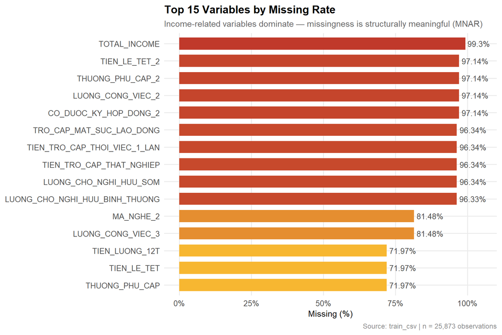

```r
missing_summary %>%
  filter(Missing_Count > 0) %>%
  slice_head(n = 15) %>%
  mutate(Variable = fct_reorder(Variable, Percent)) %>%
  ggplot(aes(x = Variable, y = Percent, fill = Percent)) +
  geom_col(width = 0.7) +
  geom_text(aes(label = paste0(Percent, "%")),
            hjust = -0.1, size = 3.5, color = "grey30") +
  coord_flip() +
  scale_fill_gradient(low = "#f7b731", high = "#c0392b") +
  scale_y_continuous(limits = c(0, 105), labels = label_percent(scale = 1)) +
  labs(
    title    = "Top 15 Variables by Missing Rate",
    subtitle = "Income-related variables dominate — missingness is structurally meaningful (MNAR)",
    x        = NULL,
    y        = "Missing (%)",
    caption  = "Source: train_csv | n = 25,873 observations"
  ) +
  theme_eda()
```

This is because:

- **Non-working population**: retirees, children, students, and the unemployed.
- **Benefit-conditional variables**: unemployment and redundancy pay are only defined for claimants.

**Preprocessing decisions:**

| Variable type | Action | Rationale |
| --- | --- | --- |
| Monetary (salary, bonus, etc.) | Replace NA → 0 | Accurately reflects zero labour income |
| Occupation code (`MA_NGHE_NGHIEP`) | Replace NA → “Unknown” | Preserves category integrity |

**Why tree-based models are preferred here:** Random Forest, XGBoost, and LightGBM can natively handle missing values, learn from missingness patterns, and manage the non-linear relationships and zero-inflation present in `y` all without requiring imputation.

## 3. Distribution of the Target Variable `y` and `log(1+y)`

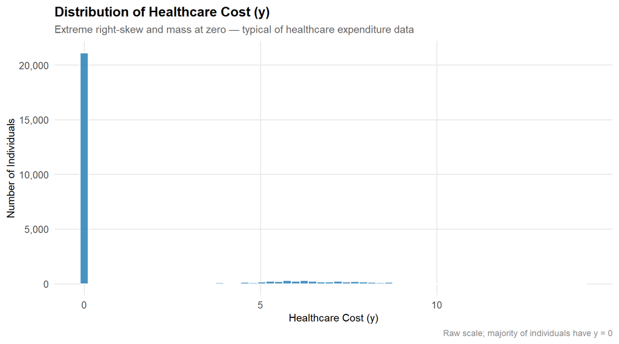

```r
ggplot(train_csv, aes(x = y)) +
  geom_histogram(bins = 60, fill = "#2980b9", color = "white", alpha = 0.85) +
  scale_x_continuous(labels = label_comma()) +
  scale_y_continuous(labels = label_comma()) +
  labs(
    title    = "Distribution of Healthcare Cost (y)",
    subtitle = "Extreme right-skew and mass at zero — typical of healthcare expenditure data",
    x        = "Healthcare Cost (y)",
    y        = "Number of Individuals",
    caption  = "Raw scale; majority of individuals have y = 0"
  ) +
  theme_eda()
```

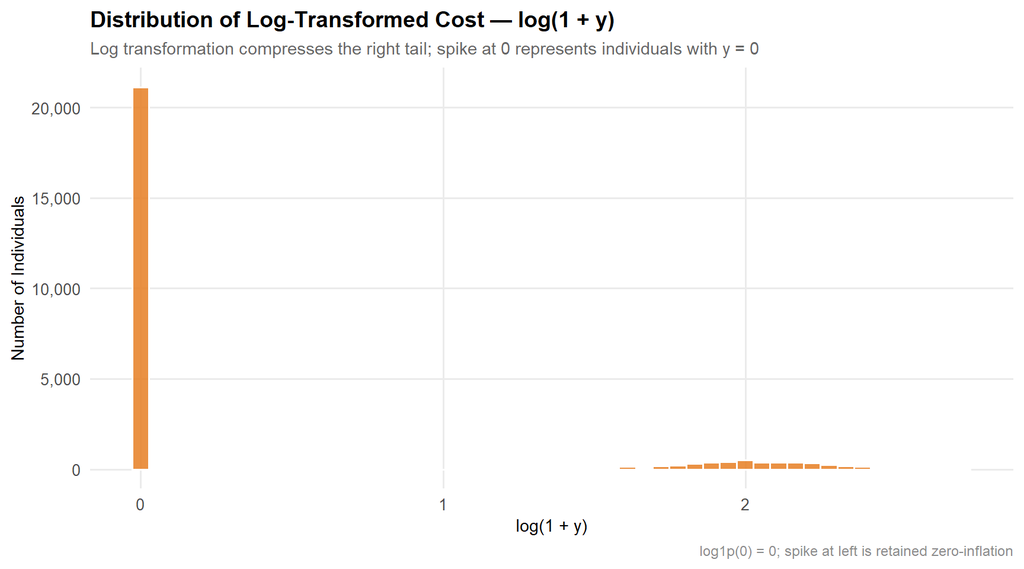

```r
ggplot(train_csv, aes(x = log_y)) +
  geom_histogram(bins = 50, fill = "#e67e22", color = "white", alpha = 0.85) +
  scale_y_continuous(labels = label_comma()) +
  labs(
    title    = "Distribution of Log-Transformed Cost — log(1 + y)",
    subtitle = "Log transformation compresses the right tail; spike at 0 represents individuals with y = 0",
    x        = "log(1 + y)",
    y        = "Number of Individuals",
    caption  = "log1p(0) = 0; spike at left is retained zero-inflation"
  ) +
  theme_eda()
```

The raw distribution of `y` shows the two hallmark features of healthcare cost data:

- **Zero-inflation**: a large mass of observations at exactly zero.
- **Extreme right-skew**: a long upper tail driven by high-cost individuals.

The `log(1 + y)` transformation compresses the tail substantially. The spike at `log_y = 0` confirms the zero-inflation is genuine. Both features must be accounted for in modelling.

## 4. Proportion of `y = 0` vs `y > 0`

```r
train_csv %>%
  mutate(y_status = ifelse(y == 0, "y = 0 (No Cost)", "y > 0 (Positive Cost)")) %>%
  count(y_status) %>%
  mutate(Percent = round(n / sum(n) * 100, 2)) %>%
  knitr::kable(
    caption = "Table 3: Proportion of Zero vs Positive Healthcare Cost",
    align   = "lrr",
    col.names = c("Cost Status", "Count", "Percent (%)"))
```

Table 3: Proportion of Zero vs Positive Healthcare Cost

| Cost Status | Count | Percent (%) |
| --- | --- | --- |
| y = 0 (No Cost) | 21129 | 81.66 |
| y > 0 (Positive Cost) | 4744 | 18.34 |

The target variable `y` (total annual healthcare cost) shows a very strong **zero-inflation** characteristic. Out of 25,873 observations, **21,129 observations (81.66%)** have `y = 0`, while only **4,744 observations (18.34%)** have positive healthcare costs.

This high proportion of zeros is typical in healthcare cost data, indicating that the majority of insured individuals did not use any medical services or had negligible costs during the year. The small group with positive costs (18.34%) is responsible for nearly all healthcare expenditure in the dataset — a common pattern known as “high-cost, low-frequency” in insurance modeling.

This characteristic has important implications for modeling: - Standard linear regression models are likely to perform poorly. - The log transformation `log(1 + y)` helps reduce skewness but does not fully resolve the zero-inflation issue. - The data is highly suitable for **tree-based models** such as Random Forest, XGBoost, or LightGBM, which can naturally handle zero values, categorical variables, missing data, and non-linear relationships.

## 5. Distribution of Age

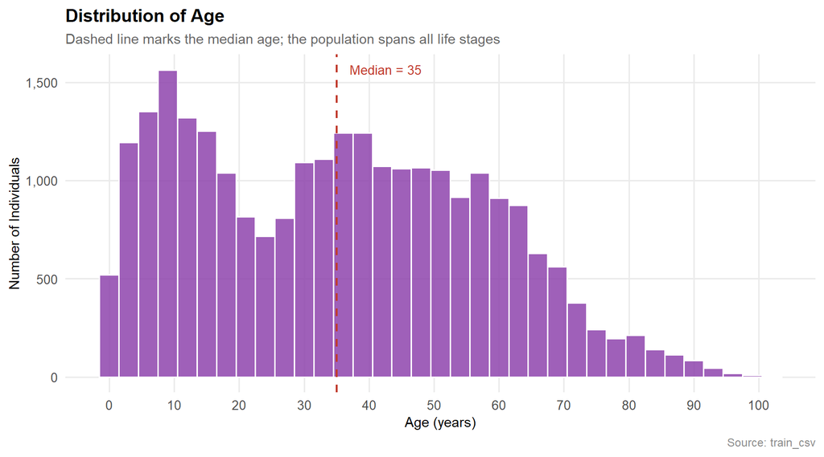

```r
ggplot(train_csv, aes(x = AGE)) +
  geom_histogram(bins = 35, fill = "#8e44ad", color = "white", alpha = 0.85) +
  scale_x_continuous(breaks = seq(0, 100, by = 10)) +
  scale_y_continuous(labels = label_comma()) +
  geom_vline(xintercept = median(train_csv$AGE, na.rm = TRUE),
             linetype = "dashed", color = "#c0392b", linewidth = 0.8) +
  annotate("text", x = median(train_csv$AGE, na.rm = TRUE) + 2,
           y = Inf, vjust = 2, hjust = 0, size = 3.5, color = "#c0392b",
           label = paste0("Median = ", round(median(train_csv$AGE, na.rm = TRUE)))) +
  labs(
    title    = "Distribution of Age",
    subtitle = "Dashed line marks the median age; the population spans all life stages",
    x        = "Age (years)",
    y        = "Number of Individuals",
    caption  = "Source: train_csv"
  ) +
  theme_eda()
```

The age distribution spans a wide range from infants to the elderly, confirming that the dataset represents the **general population**. The relatively even spread is consistent with a household-level survey or national health database. The oldest age groups will be particularly important predictors of `y`, as healthcare costs typically escalate sharply with age.

## 6. Relationship Between Age and Log(1+y)

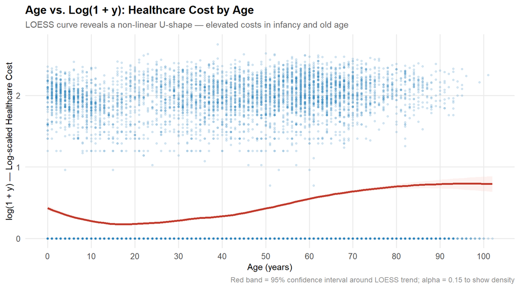

```r
ggplot(train_csv, aes(x = AGE, y = log_y)) +
  geom_point(alpha = 0.15, color = "#2980b9", size = 0.9) +
  geom_smooth(method = "loess", color = "#c0392b",
              linewidth = 1.2, se = TRUE, fill = "#fadbd8") +
  scale_x_continuous(breaks = seq(0, 100, by = 10)) +
  labs(
    title    = "Age vs. Log(1 + y): Healthcare Cost by Age",
    subtitle = "LOESS curve reveals a non-linear U-shape — elevated costs in infancy and old age",
    x        = "Age (years)",
    y        = "log(1 + y) — Log-scaled Healthcare Cost",
    caption  = "Red band = 95% confidence interval around LOESS trend; alpha = 0.15 to show density"
  ) +
  theme_eda()
```

The LOESS smooth reveals a clear **non-linear, U-shaped relationship**:

This non-linearity confirms that a **tree-based model** or **polynomial/spline regression** will outperform a plain linear model for this feature.

## 7. Comparison of log(1+y) Across Demographic Groups

```r
# ── Convert numeric-coded categoricals to labeled factors ─────────────────
train_csv <- train_csv %>%
  mutate(
    GENDER_f = factor(GENDER,
                      levels = c(1, 2),
                      labels = c("Male", "Female")),

    INSURANCE_f = factor(CO_THE_BAO_HIEM,
                         levels = c(0, 1),
                         labels = c("Not Insured", "Insured")),

    EMPLOYED_f = factor(CO_LAM_VIEC,
                        levels = c(1, 2),
                        labels = c("Working", "Not Working")),

    MARRIED_f = factor(MARRIED_STATUS,
                       levels = c(1, 2, 3, 4, 5),
                       labels = c("Single", "Married", "Divorced", "Separated", "Widowed")),

    OCC_f = factor(ifelse(is.na(MA_NGHE_NGHIEP) | MA_NGHE_NGHIEP == "",
                          "Unknown", as.character(MA_NGHE_NGHIEP)))
  )
```

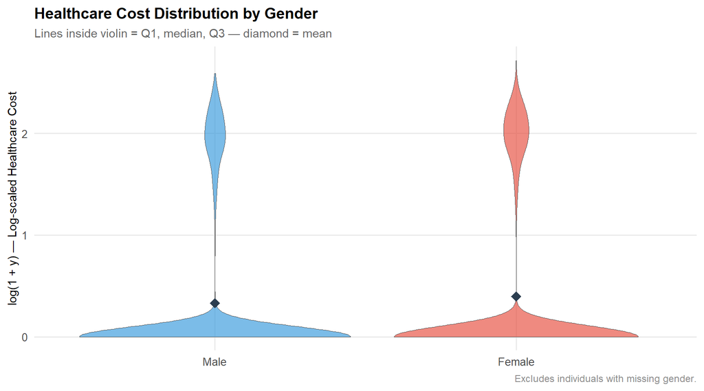

```r
gender_data <- train_csv %>% filter(!is.na(GENDER_f))

ggplot(gender_data, aes(x = GENDER_f, y = log_y, fill = GENDER_f)) +
  geom_violin(
    trim = TRUE, alpha = 0.65,
    color = "grey30", linewidth = 0.35,
    draw_quantiles = c(0.25, 0.5, 0.75)
  ) +
  stat_summary(fun = mean, geom = "point", shape = 18,
               size = 4, color = "#2c3e50") +
  scale_fill_manual(values = c("Male" = "#3498db", "Female" = "#e74c3c")) +
  scale_y_continuous(breaks = 0:4) +
  labs(
    title    = "Healthcare Cost Distribution by Gender",
    subtitle = "Lines inside violin = Q1, median, Q3 — diamond = mean",
    x        = NULL,
    y        = "log(1 + y) — Log-scaled Healthcare Cost",
    caption  = "Excludes individuals with missing gender."
  ) +
  theme_eda()
```

```r
train_csv %>%
  filter(!is.na(EMPLOYED_f), !is.na(INSURANCE_f)) %>%
  count(EMPLOYED_f, INSURANCE_f) %>%
  mutate(Pct = round(n / sum(n) * 100, 1)) %>%
  knitr::kable(
    caption   = "Table: Insurance Coverage by Employment Status",
    align     = "llrr",
    col.names = c("Employment", "Insurance", "Count", "% of total"))
```

Table: Insurance Coverage by Employment Status

| Employment | Insurance | Count | % of total |
| --- | --- | --- | --- |
| Working | Not Insured | 2133 | 9.0 |
| Working | Insured | 12778 | 53.8 |
| Not Working | Not Insured | 567 | 2.4 |
| Not Working | Insured | 8263 | 34.8 |

> **Note:** In Vietnam, the state provides BHYT health insurance cards to unemployed and non-working citizens. The “Insured” group therefore contains both premium-paying workers and non-workers.

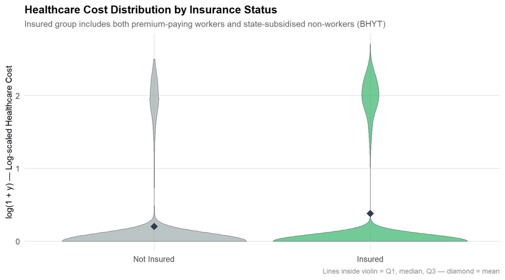

```r
ins_data <- train_csv %>% filter(!is.na(INSURANCE_f))

ggplot(ins_data, aes(x = INSURANCE_f, y = log_y, fill = INSURANCE_f)) +
  geom_violin(
    trim = TRUE, alpha = 0.65,
    color = "grey30", linewidth = 0.35,
    draw_quantiles = c(0.25, 0.5, 0.75)
  ) +
  stat_summary(fun = mean, geom = "point", shape = 18,
               size = 4, color = "#2c3e50") +
  scale_fill_manual(values = c("Not Insured" = "#95a5a6", "Insured" = "#27ae60")) +
  scale_y_continuous(breaks = 0:4) +
  labs(
    title    = "Healthcare Cost Distribution by Insurance Status",
    subtitle = "Insured group includes both premium-paying workers and state-subsidised non-workers (BHYT)",
    x        = NULL,
    y        = "log(1 + y) — Log-scaled Healthcare Cost",
    caption  = "Lines inside violin = Q1, median, Q3 — diamond = mean"
  ) +
  theme_eda()
```

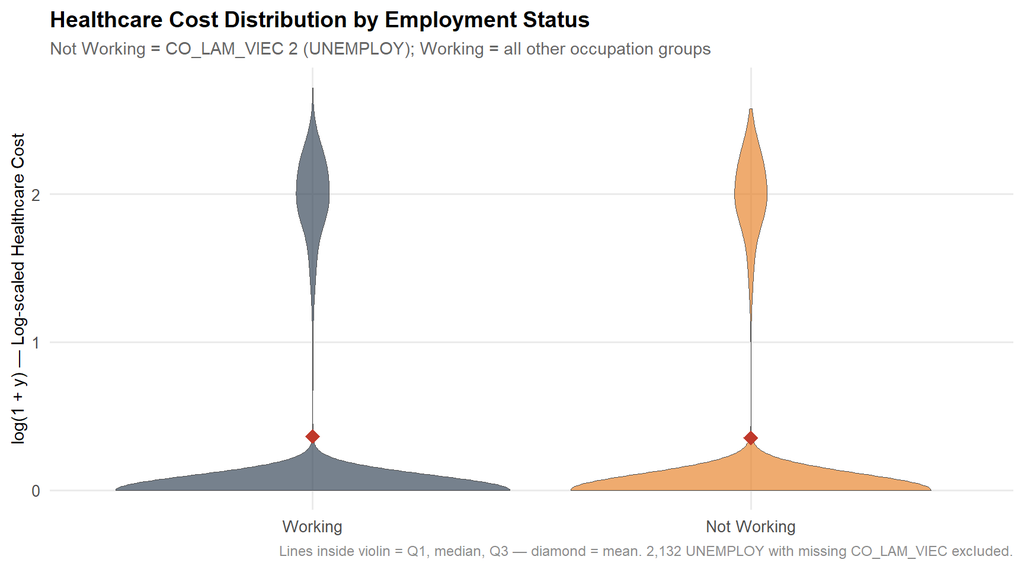

```r
emp_data <- train_csv %>% filter(!is.na(EMPLOYED_f))

ggplot(emp_data, aes(x = EMPLOYED_f, y = log_y, fill = EMPLOYED_f)) +
  geom_violin(
    trim = TRUE, alpha = 0.65,
    color = "grey30", linewidth = 0.35,
    draw_quantiles = c(0.25, 0.5, 0.75)
  ) +
  stat_summary(fun = mean, geom = "point", shape = 18,
               size = 4, color = "#c0392b") +
  scale_fill_manual(values = c("Not Working" = "#e67e22", "Working" = "#2c3e50")) +
  scale_y_continuous(breaks = 0:4) +
  labs(
    title    = "Healthcare Cost Distribution by Employment Status",
    subtitle = "Not Working = CO_LAM_VIEC 2 (UNEMPLOY); Working = all other occupation groups",
    x        = NULL,
    y        = "log(1 + y) — Log-scaled Healthcare Cost",
    caption  = "Lines inside violin = Q1, median, Q3 — diamond = mean. 2,132 UNEMPLOY with missing CO_LAM_VIEC excluded."
  ) +
  theme_eda()
```

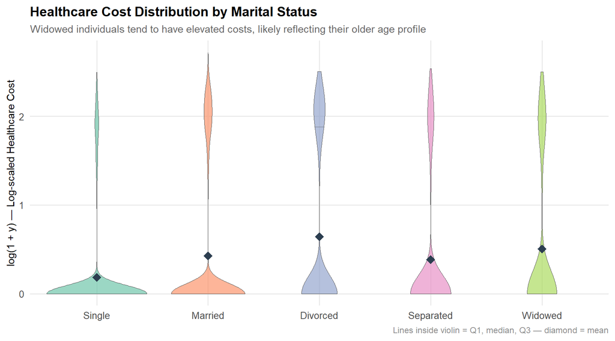

```r
mar_data <- train_csv %>% filter(!is.na(MARRIED_f))

ggplot(mar_data, aes(x = MARRIED_f, y = log_y, fill = MARRIED_f)) +
  geom_violin(
    trim = TRUE, alpha = 0.65,
    color = "grey30", linewidth = 0.35,
    draw_quantiles = c(0.25, 0.5, 0.75)
  ) +
  stat_summary(fun = mean, geom = "point", shape = 18,
               size = 4, color = "#2c3e50") +
  scale_fill_brewer(palette = "Set2") +
  scale_y_continuous(breaks = 0:4) +
  labs(
    title    = "Healthcare Cost Distribution by Marital Status",
    subtitle = "Widowed individuals tend to have elevated costs, likely reflecting their older age profile",
    x        = NULL,
    y        = "log(1 + y) — Log-scaled Healthcare Cost",
    caption  = "Lines inside violin = Q1, median, Q3 — diamond = mean"
  ) +
  theme_eda()
```

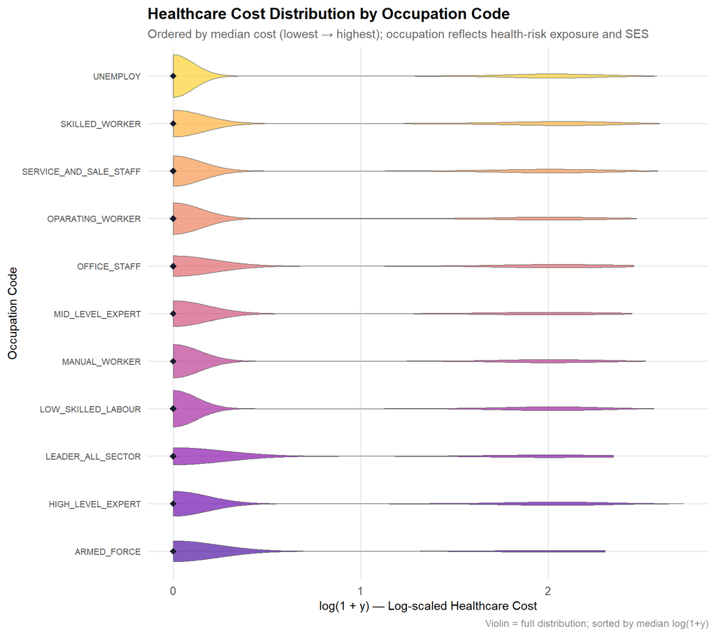

```r
occ_data <- train_csv %>%
  filter(!is.na(OCC_f)) %>%
  mutate(OCC_f = fct_reorder(OCC_f, log_y, .fun = median, na.rm = TRUE))

ggplot(occ_data, aes(x = OCC_f, y = log_y, fill = OCC_f)) +
  geom_violin(
    trim = TRUE, alpha = 0.65,
    color = "grey30", linewidth = 0.3,
    draw_quantiles = c(0.25, 0.5, 0.75)
  ) +
  stat_summary(fun = median, geom = "point", shape = 18,
               size = 2.5, color = "#1a1a2e") +
  coord_flip() +
  scale_fill_viridis_d(option = "plasma", begin = 0.1, end = 0.9) +
  scale_y_continuous(breaks = 0:4) +
  labs(
    title    = "Healthcare Cost Distribution by Occupation Code",
    subtitle = "Ordered by median cost (lowest → highest); occupation reflects health-risk exposure and SES",
    x        = "Occupation Code",
    y        = "log(1 + y) — Log-scaled Healthcare Cost",
    caption  = "Violin = full distribution; sorted by median log(1+y)"
  ) +
  theme_eda() +
  theme(axis.text.y = element_text(size = 8),
        legend.position = "none")
```